# Modelos de Gráficos usando o ggplot

Fernando Bastos

11/08/2020

## ggplot

O ggplot2 é um pacote de visualização de dados para a linguagem de programação estatística R. Criado por Hadley Wickham em 2005, o ggplot2 é uma implementação da Grammar of Graphics de Leland Wilkinson - um esquema geral para visualização de dados que divide gráficos em componentes semânticos, como escalas e camadas (Wikipédia).

Primeiro vamos considerar um banco de dados. Considere o banco de dados já na base do R chamado mtcars.

```r
dados <- mtcars
head(dados)
```

```
##                    mpg cyl disp  hp drat    wt  qsec vs am gear carb
## Mazda RX4         21.0   6  160 110 3.90 2.620 16.46  0  1    4    4
## Mazda RX4 Wag     21.0   6  160 110 3.90 2.875 17.02  0  1    4    4
## Datsun 710        22.8   4  108  93 3.85 2.320 18.61  1  1    4    1
## Hornet 4 Drive    21.4   6  258 110 3.08 3.215 19.44  1  0    3    1
## Hornet Sportabout 18.7   8  360 175 3.15 3.440 17.02  0  0    3    2
## Valiant           18.1   6  225 105 2.76 3.460 20.22  1  0    3    1
```

```r
str(dados)
```

```
## 'data.frame':    32 obs. of  11 variables:
##  $ mpg : num  21 21 22.8 21.4 18.7 18.1 14.3 24.4 22.8 19.2 ...
##  $ cyl : num  6 6 4 6 8 6 8 4 4 6 ...
##  $ disp: num  160 160 108 258 360 ...
##  $ hp  : num  110 110 93 110 175 105 245 62 95 123 ...
##  $ drat: num  3.9 3.9 3.85 3.08 3.15 2.76 3.21 3.69 3.92 3.92 ...
##  $ wt  : num  2.62 2.88 2.32 3.21 3.44 ...
##  $ qsec: num  16.5 17 18.6 19.4 17 ...
##  $ vs  : num  0 0 1 1 0 1 0 1 1 1 ...
##  $ am  : num  1 1 1 0 0 0 0 0 0 0 ...
##  $ gear: num  4 4 4 3 3 3 3 4 4 4 ...
##  $ carb: num  4 4 1 1 2 1 4 2 2 4 ...
```

```r
dados$cyl  <- as.factor(dados$cyl )
dados$vs   <- as.factor(dados$vs  )
dados$am   <- as.factor(dados$am  )
dados$gear <- as.factor(dados$gear)
dados$carb <- as.factor(dados$carb)
```

Agora já podemos começar a exemplificar o uso do pacote ggplot. Chamamos o pacote:

```r
library(ggplot2)
```

Como não podemos deixar de usar o operador pipe (%>%) chamamos também o pacote:

```r
library(tidyverse)
```

Pronto, agora mãos a obra. No ggplot2, os gráficos são construídos camada por camada (ou, *layers*, em inglês), sendo que a primeira delas é dada pela função ggplot (não tem o “2”). O primeiro argumento é o banco de dados:

```r
ggplot()
```

Nesse caso, foi alocado um espaço para a construção do gráfico. É como se dissessemos para o R, “vou construir um gráfico aqui!”.

Continuando, o primeiro argumento é o banco de dados, que pode ser acrescentado de duas formas, assim:

```r
ggplot(dados)
```

ou assim:

```r
dados %>% ggplot()
```

Ainda não visualizamos nada, somente alocamos o espaço para o gráfico. O segundo passo é determinar a relação entre os dados e cada aspecto visual do gráfico, como qual variável será representada no eixo x, qual será representada no eixo y, a cor e o tamanho dos componentes geométricos etc. Os aspectos que podem ou devem ser mapeados depende do tipo de gráfico que você deseja fazer. Esse passo é feito com a função *aes()*. É dentro desta função que indicamos para o R as variáveis a serem utilizadas na construção do gráfico. Por exemplo, suponha que queiramos utilizar o número de cilindros no eixo x. Fazemos então:

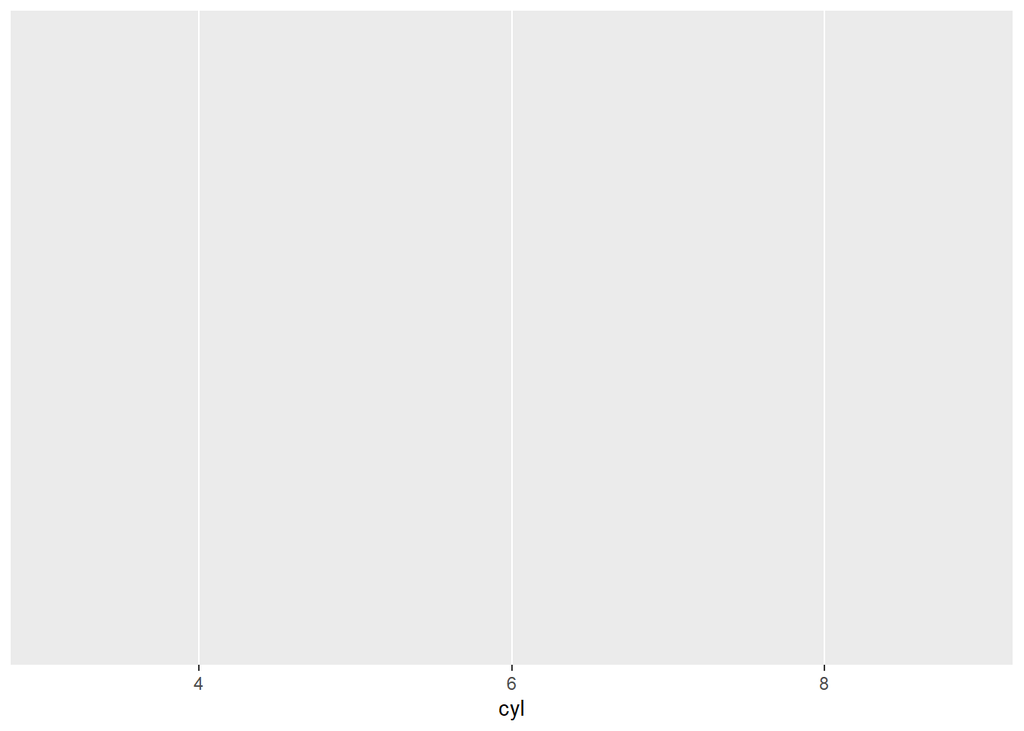

```r
dados %>% ggplot(aes(cyl))
```

Podemos ainda indicar também o eixo y:

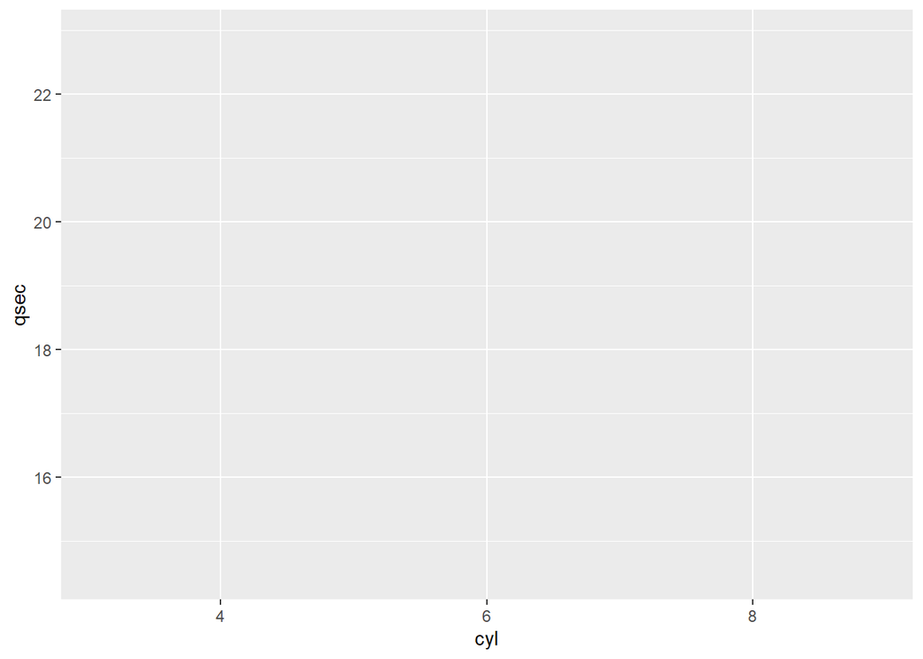

```r
dados %>% ggplot(aes(cyl,qsec))
```

Observem que o gráfico ainda não foi criado, para isso, precisamos indicar qual gráfico desejamos. Pode ser vários, por exemplo:

- geom_line: para retas definidas por pares (x,y)
- geom_abline: para retas definidas por um intercepto e uma inclinação
- geom_hline: para retas horizontais
- geom_boxplot: para boxplots
- geom_histogram: para histogramas
- geom_density: para densidades
- geom_area: para áreas
- geom_bar: para barras

No caso de nossas variáveis vamos utilizar um boxplot, fazemos então:

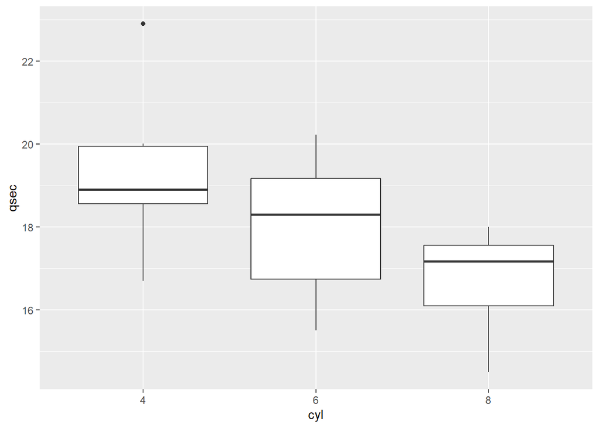

```r
dados %>% ggplot(aes(cyl, qsec)) + geom_boxplot()
```

Observe que nesse caso funcionou perfeitamente bem, pois já indicamos anteriormente que a variável *cyl* é um fator, caso contrário, teríamos que fazer:

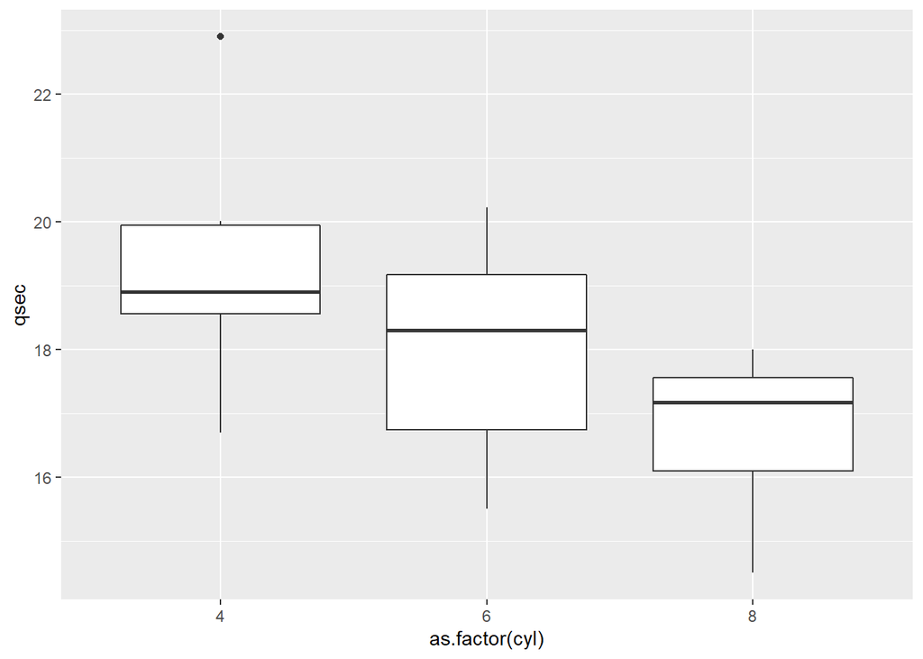

```r
dados %>% ggplot(aes(as.factor(cyl), qsec)) + geom_boxplot()
```

se quisermos fazer um histograma, basta indicar a variável, fazemos da seguinte forma:

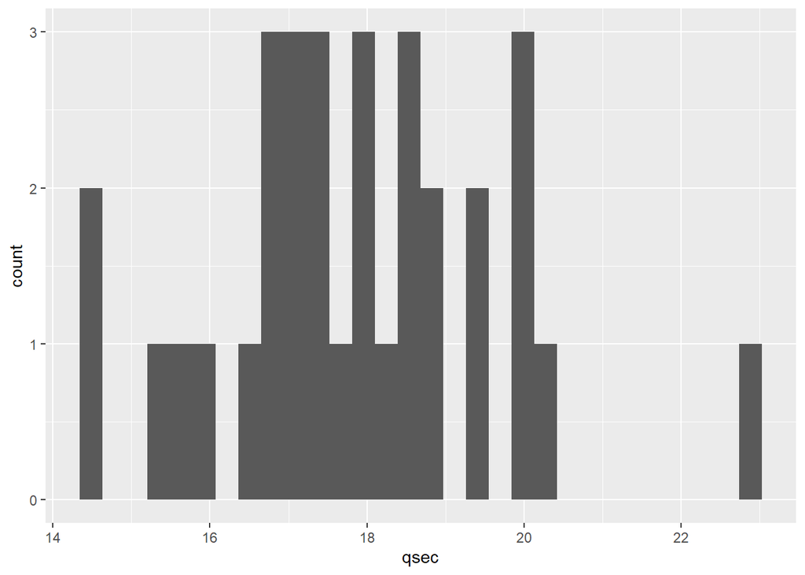

```r
dados %>% ggplot(aes(qsec)) + geom_histogram()
```

Podemos ainda escolher diversos temas:

- theme_gray (): Cor de fundo cinza e linhas de grade brancas. Apresente os dados para facilitar as comparações.
- theme_bw (): Fundo branco e linhas de grade cinza. Pode funcionar melhor para apresentações exibidas com um projetor.
- theme_linedraw (): Um tema com linhas pretas de várias larguras em fundos brancos, uma reminiscência de desenhos de linha.
- theme_light (): Um tema semelhante a theme_linedraw (), mas com linhas e eixos cinza claro, para direcionar mais atenção para os dados.
- theme_dark (): O mesmo que theme_light, mas com um fundo escuro. Útil para destacar linhas finas coloridas.
- theme_minimal (): Um tema mínimo sem anotações de fundo
- theme_classic (): Um tema clássico, com linhas dos eixos xey e sem linhas de grade.
- theme_void (): um tema completamente vazio, útil para plotagens com coordenadas não padronizadas ou para desenhos.

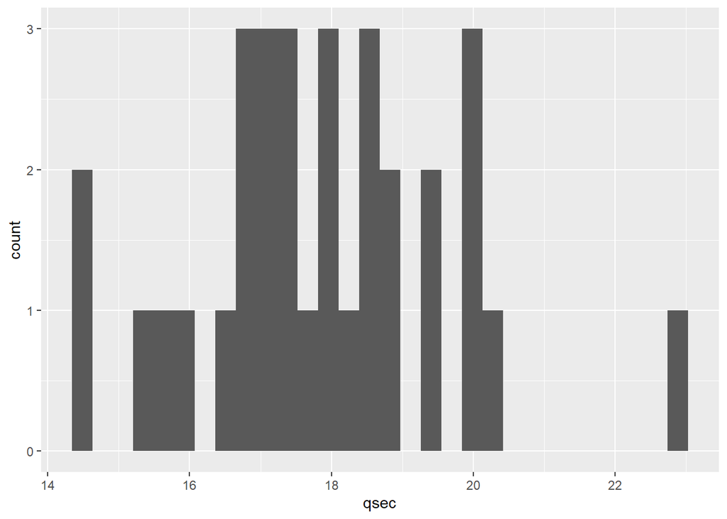

```r
p <- dados %>% ggplot(aes(qsec)) + geom_histogram()
p + theme_gray()
```

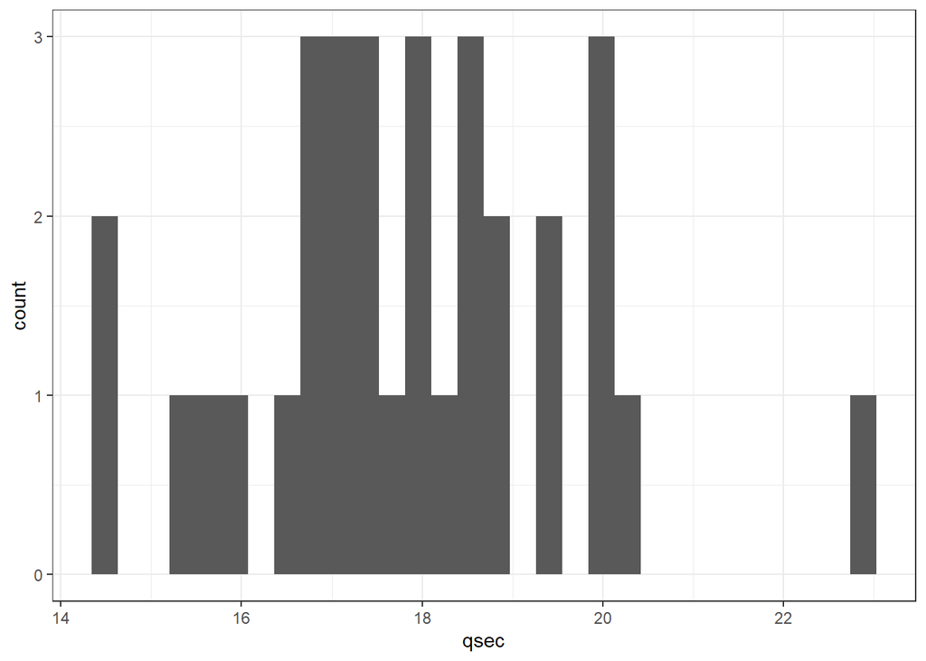

```r
p + theme_bw()
```

O pacote R ggthemes fornece outra galeria de temas personalizados do ggplot, que incluem:

- theme_tufte (): um tema minimalista
- theme_economist (): tema baseado nos enredos da revista economist
- theme_stata (): tema baseado em esquemas de gráficos estatísticos.
- theme_hc (): tema baseado em Highcharts JS

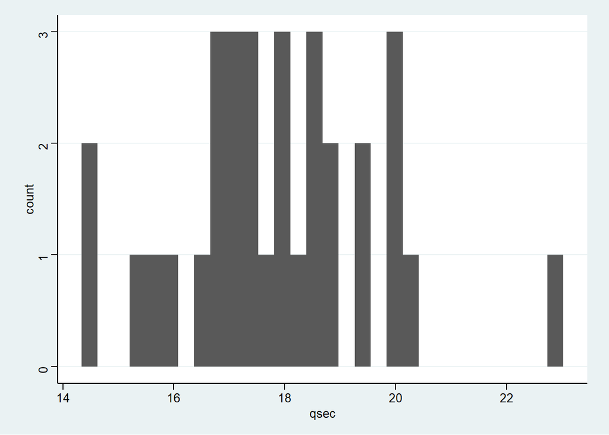

```r
library(ggthemes)
p + theme_stata()
```

Podemos mudar as cores das variáveis com o comando col, vejamos:

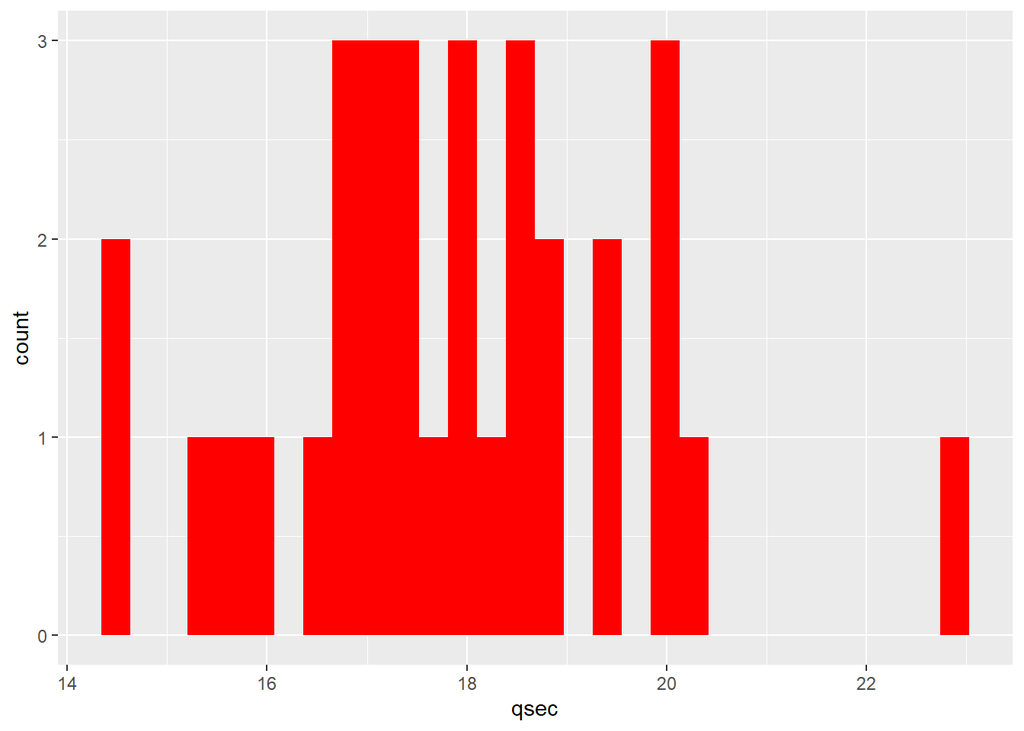

```r
dados %>% ggplot(aes(qsec)) + geom_histogram(fill="red")
```

Podemos ainda alterar o número de categorias, utilizando:

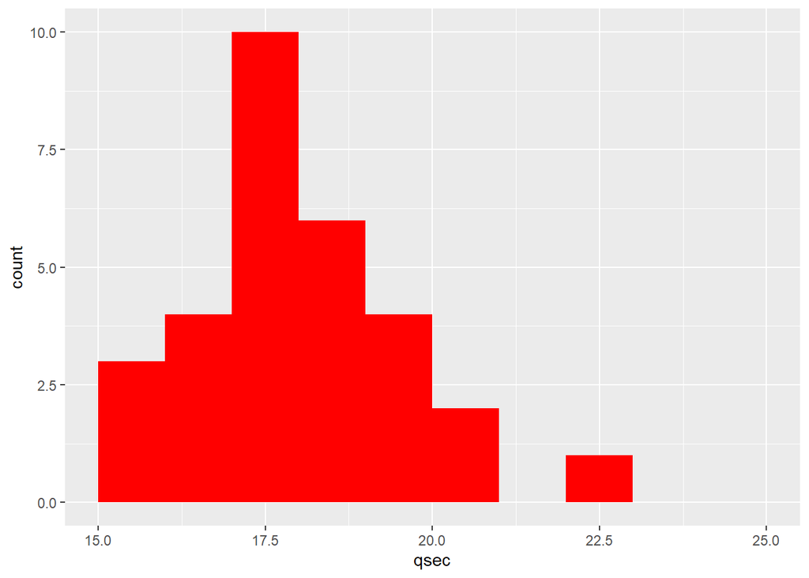

```r
dados %>% ggplot(aes(qsec)) + geom_histogram(breaks=seq(15, 25, by=1),fill="red")
```